# CS02 - Right-To-Carry

Adrian Castaneda, Garvin Mo Zhen, Melvin Chang

## Introduction

In this case study, we seek to analyze the effect of multicollinearity on coefficient estimates from linear regression models when analyzing right to carry laws and violence rates. In the United States of America, the issue of gun violence has consistently become a controversial issue considering how impactful misusage has been since the inception of this country. Such misusages have included school shootings, shootings at festivals/clubs, and general gun violence out in the public streets. As such to prevent such atrocities from occurring, attempts have been made to minimize this through Right to Carry (RTC) Laws. Such laws are laws that “specifies if an how citizens are allowed to have a firearm on their person or nearby (for example, in a citizen’s car) in public” (Slide 4, CS02: Right-To-Carry (Data)).

Such laws are created and carried out at the US state level. The only federal law regarding the right to keep and bear arms is our Second Amendment in the Bill of Rights which was ratified in 1791 (Slide 5, CS02: Right-To-Carry (Data)). A time period where muskets would be easily outclassed by our current firearm models. There are no such laws for carrying firearms in the public. Furthermore, severity for such laws vary greatly between states regarding the right to carry firearms. For example, some states such as California require extensive effort to obtain a permit to legally carry a firearm, whereas other states like Arizona allows individuals to carry concealed firearms for lawful purposes without a permit. There are also other states who meet at a middle ground and grants permits to carry a firearm upon the completion of specified requirements (Slide 5, CS02: Right-To-Carry (Data)). Analyzing the effect of multicollinearity on coefficient estimates from our linear regression models may serve to give us a better understanding of what kind of role a certain variable may play.

### Load packages

```r
library(OCSdata)
library(tidyverse)
library(pdftools)
library(readxl)
library(skimr)
library(ggrepel)
library(broom)
library(plm)
library(car)
library(rsample)
library(GGally)
library(ggcorrplot)
```

## Question

What is the effect of multicollinearity on coefficient estimates from linear regression models when analyzing right to carry laws and violence rates?

## The Data

The dataset that we will be using for our case study is sourced from two contradictory analyses. The first is from John J. Donohue et al., in their analysis Right-to-Carry Laws and Violent Crime: A Comprehensive Assessment Using Panel Data and a State-Level Synthetic Control Analysis. The second is from David B. Mustard & John Lott and their analysis Crime, Deterrence, and Right-to-Carry Concealed Handguns. Coase-Sandor Institute for Law & Economics Working Paper No. 41.

### Data Import

```r
# OCSdata::load_raw_data("ocs-bp-RTC-wrangling", outpath = '.')

# reads in xls file, skips first 5 lines
STATE_FIPS <- readxl::read_xls("data/raw/State_FIPS_codes/state-geocodes-v2014.xls", skip = 5)

# reads in csv from given the path to the file
ps_data <- read_csv("data/raw/Police_staffing/ps_data.csv")
```

```r
# converts raw data into readable format, skips first 10 lines
ue_rate_data <- list.files(recursive = TRUE,
                            path = "data/raw/Unemployment",
                            pattern = "*.xlsx",
                            full.names = TRUE) |>
  map(~read_xlsx(., skip = 10))
```

Demographic/Population data:

Since we are starting with raw data, we need to convert what we have into a useable R data. We began by reading the raw data as a csv assigning it a tibble object for each decade.

```r
# Create tibble from csv and skip five lines before reading the data
dem_77_79 <- read_csv("data/raw/Demographics/Decade_1970/pe-19.csv", skip = 5) # Import from csv and skip five lines before reading the data

# Convert raw data into a csv file, create tibble, and skip 5 lines before reading the data
dem_80_89 <- list.files(recursive = TRUE,
                  path = "data/raw/Demographics/Decade_1980",
                  pattern = "*.csv",
                  full.names = TRUE) |>
  purrr::map(~read_csv(., skip=5))

# Convert raw data into a csv file, create tibble, and skip 14 lines before reading the data
dem_90_99 <- list.files(recursive = TRUE,
                  path = "data/raw/Demographics/Decade_1990",
                  pattern = "*.txt",
                  full.names = TRUE) |>
  map(~read_table2(., skip = 14))

# Convert raw data into a csv file and create tibble
dem_00_10 <- list.files(recursive = TRUE,
                  path = "data/raw/Demographics/Decade_2000",
                  pattern = "*.csv",
                   full.names = TRUE) |>
   map(~read_csv(.))
```

### Data Wrangling

Demographic/Population Data:

Now that we have our data properly imported, we need to wrangle our data in R so we can begin our analysis. To support our demographic and population data, we need to quickly wrangle the FIPS data.

```r
STATE_FIPS <- STATE_FIPS |>
  # Rename columns
  rename(STATEFP = `State\n(FIPS)`,
         STATE = Name) |>
  select(STATEFP, STATE) |> # Only keep STATEFP and STATE columns
  filter(STATEFP != "00") # Filter out STATEFP not equal to 00
```

Moving to our demographic and population data, we started with the 70s data. We wrangled the data by assigning and creating specific race, sex, age group, and sub population columns while removing years before 1977 from the existing columns and removing any redundant columns afterwards.

```r
dem_77_79 <- dem_77_79 |>
  rename("race_sex" =`Race/Sex Indicator`) |> # Rename column
  # Create sex and race columns
  mutate(SEX = str_extract(race_sex, "male|female"), # Extract sex from the race_sex column
        RACE = str_extract(race_sex, "Black|White|Other"))|> # Extract race from the race_sex column
  select(-`FIPS State Code`, -`race_sex`) |> # Delete FIPS State Code and race_sex columns as they are now separated into different columns
  # Simplify column names
  rename("YEAR" = `Year of Estimate`,
        "STATE" = `State Name`) |>
  filter(YEAR %in% 1977:1979) # Filter for only years 1977-79
dem_77_79 <- dem_77_79 |>
  # Moves demographic data into rows with age group and sub populations as columns
  pivot_longer(cols=contains("years"),
               names_to = "AGE_GROUP",
               values_to = "SUB_POP")
```

We wrangled the 80s data similarly to the 70s data by assigning and creating specific race, sex, age group, and sub population columns from the existing columns and removing any redundant columns afterwards.

```r
# Make the 80s data into a data frame
dem_80_89 <- dem_80_89 |>
  map_df(bind_rows)
dem_80_89 <- dem_80_89 |>
  rename("race_sex" =`Race/Sex Indicator`) |> # Rename column
  # Create sex and race columns
  mutate(SEX = str_extract(race_sex, "male|female"), # Extract sex from the race_sex column
        RACE = str_extract(race_sex, "Black|White|Other"))|> # Extract race from the race_sex column
  select( -`race_sex`) |> # Delete race_sex column as they are now separated into different columns
  rename("YEAR" = `Year of Estimate`) |>  # Simplify column name
  rename("STATEFP_temp" = "FIPS State and County Codes") |>
  mutate(STATEFP = str_sub(STATEFP_temp, start = 1, end = 2)) |>
    left_join(STATE_FIPS, by = "STATEFP") |>
  select(-STATEFP) # Delete STATEFP column because it is no longer needed
dem_80_89 <- dem_80_89 |>
  # Moves demographic data into rows with age group and sub populations as columns
  pivot_longer(cols=contains("years"),
               names_to = "AGE_GROUP",
               values_to = "SUB_POP_temp") |>
  group_by(YEAR, STATE, AGE_GROUP, SEX, RACE) |>
  summarize(SUB_POP = sum(SUB_POP_temp), .groups="drop")
```

Wrangling the 90s data took a few more steps in assigning column names, adding columns, and adding age groups, but we ended up with the same outcome of creating specific race, sex, age group, and sub population columns from the existing columns and removing any redundant columns afterwards.

```r
# Make the 90s data into a data frame
dem_90_99 <- dem_90_99 |>
  map_df(bind_rows)
# Create column names
colnames(dem_90_99) <- c("YEAR", "STATEFP", "Age", "NH_W_M", "NH_W_F", "NH_B_M",
                         "NH_B_F", "NH_AIAN_M", "NH_AIAN_F", "NH_API_M", "NH_API_F",
                         "H_W_M", "H_W_F", "H_B_M", "H_B_F", "H_AIAN_M", "H_AIAN_F",
                         "H_API_M", "H_API_F")
dem_90_99 <- dem_90_99 |>
  drop_na() |> # Drop NA rows
  # Add columns to create total demo/pop columns
  mutate(W_M = NH_W_M + H_W_M, W_F = NH_W_F + H_W_F,
         B_M = NH_B_M + H_B_M, B_F = NH_B_F + H_B_F,
         AIAN_M = NH_AIAN_M + H_AIAN_M, AIAN_F = NH_AIAN_F + H_AIAN_F,
         API_M = NH_API_M + H_API_M, API_F = NH_API_F + H_API_F) |>
  select(-starts_with("NH_"), -starts_with("H_")) # Drops columns no longer needed

dem_90_99 <- dem_90_99 |>
  # Create column for age group
  mutate(AGE_GROUP = cut(Age,
                         breaks = seq(0, 90, by=5),
                         right = FALSE, labels = pull(distinct(dem_77_79,AGE_GROUP), AGE_GROUP))) |>
  select(-Age) |> # Delete age column as we now have age groups
  # Moves demographic data into rows with race and sub populations as columns
  pivot_longer(cols = c(starts_with("W_"),
                        starts_with("B_"),
                        starts_with("AIAN_"),
                        starts_with("API_")),
               names_to = "RACE",
               values_to = "SUB_POP_temp") |>
  # Create sex and race columns
  mutate(SEX = case_when(str_detect(RACE, "_M") ~ "Male",
                         TRUE ~ "Female"),
         RACE = case_when(str_detect(RACE, "W_") ~ "White",
                          str_detect(RACE, "B_") ~ "Black",
                          TRUE ~ "Other"))
dem_90_99 <- dem_90_99 |>
  # Cleans up columns
  left_join(STATE_FIPS, by = "STATEFP") |>
  select(-STATEFP) |>
  group_by(YEAR, STATE, AGE_GROUP, SEX, RACE) |>
  summarize(SUB_POP = sum(SUB_POP_temp), .groups="drop")
```

Wrangling the 00s data was simpler than the 90s data but still had some additional steps of dropping unneeded columns and filtering for desired data to create specific race, sex, age group, and sub population columns.

```r
# Make the 00s data into a data frame
dem_00_10 <- dem_00_10 |>
  map_df(bind_rows)
dem_00_10 <- dem_00_10 |>
  select(-ESTIMATESBASE2000,-CENSUS2010POP) |> # Delete columns not needed
  # Filter for desired data
  filter(NAME != "United States",
         SEX != 0,
         RACE != 0,
         AGEGRP != 0,
         ORIGIN == 0) |>
  select(-REGION, -DIVISION, -ORIGIN, -STATE) |> # Delete columns not needed
  # Simplify column names
  rename("STATE" = NAME,
         "AGE_GROUP" = AGEGRP)
dem_00_10 <- dem_00_10 |>
  # Create sex, race, and age group columns
  mutate(SEX = factor(SEX, levels = 1:2, labels = c("Male", "Female")),
         RACE = factor(RACE, levels = 1:6, labels = c("White", "Black", rep("Other",4))),
         AGE_GROUP = factor(AGE_GROUP, levels = 1:18,
                            labels = pull(distinct(dem_77_79,AGE_GROUP), AGE_GROUP)))
dem_00_10 <- dem_00_10 |>
  # Moves demographic data into rows with race and sub populations as columns
  pivot_longer(cols=contains("ESTIMATE"), names_to = "YEAR", values_to = "SUB_POP_temp") |>
   mutate(YEAR = str_sub(YEAR, start=-4),
          YEAR = as.numeric(YEAR)) |>
  group_by(YEAR, AGE_GROUP, STATE, SEX, RACE) |>
  summarize(SUB_POP = sum(SUB_POP_temp), .groups = "drop")
```

To get our total population data, we sum from our demographic data starting with the 70s.

```r
# 70s population data
pop_77_79 <- dem_77_79 |>
  # Add sub populations by year and state to get total population
  group_by(YEAR, STATE) |>
  summarize(TOT_POP = sum(SUB_POP), .groups = "drop")
```

Similarly, we get our population data for 80s, 90s, and 00s.

```r
# 80s population data
pop_80_89 <- dem_80_89 |>
  group_by(YEAR, STATE) |>
  summarize(TOT_POP = sum(SUB_POP), .groups = "drop")

# 90s population data
pop_90_99 <- dem_90_99 |>
  group_by(YEAR, STATE) |>
  summarize(TOT_POP = sum(SUB_POP), .groups = "drop")

# 00s population data
pop_00_10 <- dem_00_10 |>
  group_by(YEAR, STATE) |>
  summarize(TOT_POP = sum(SUB_POP), .groups = "drop")
```

We now need to combine our demographic and population data for each decade.

```r
# Combine 70s demographic and population data
dem_77_79 <- dem_77_79 |>
  # Join data by year and state
  left_join(pop_77_79, by = c("YEAR", "STATE")) |>
  # Create percent of total population column
  mutate(PERC_SUB_POP = (SUB_POP/TOT_POP)*100) |>
  select(-SUB_POP, -TOT_POP) |> # Delete sub and total population columns since they are now redundant
    mutate(SEX = str_to_title(SEX)) # Title sex column

# Combine 80s data similarly to 70s
dem_80_89 <- dem_80_89 |>
  left_join(pop_80_89, by = c("YEAR", "STATE")) |>
  mutate(PERC_SUB_POP = (SUB_POP/TOT_POP)*100) |>
  select(-SUB_POP, -TOT_POP) |>
  mutate(SEX = str_to_title(SEX))

# Combine 90s data similarly to 70s
dem_90_99 <- dem_90_99 |>
  left_join(pop_90_99, by = c("YEAR", "STATE")) |>
  mutate(PERC_SUB_POP = (SUB_POP/TOT_POP)*100) |>
  select(-SUB_POP, -TOT_POP)

# Combine 00s data similarly to 70s
dem_00_10 <- dem_00_10 |>
  left_join(pop_00_10, by = c("YEAR", "STATE")) |>
  mutate(PERC_SUB_POP = (SUB_POP/TOT_POP)*100) |>
 select(-SUB_POP, -TOT_POP)
```

We can now combine all of our data for each decade into one data set.

```r
dem <- bind_rows(dem_77_79,
                 dem_80_89,
                 dem_90_99,
                 dem_00_10)
```

Having finished the general demographic data, we moved onto the Donahue demographic data. The wrangled data set results in containing year, state, demographic variable, and value columns.

```r
# Create age groups
DONOHUE_AGE_GROUPS <- c("15 to 19 years",
                        "20 to 24 years",
                        "25 to 29 years",
                        "30 to 34 years",
                        "35 to 39 years")
dem_DONOHUE <- dem |>
  # Filter for males and desired age groups
  filter(AGE_GROUP %in% DONOHUE_AGE_GROUPS,
               SEX == "Male") |>
  # Combine age groups
  mutate(AGE_GROUP = fct_collapse(AGE_GROUP, "20 to 39 years"=c("20 to 24 years",
                                                                "25 to 29 years",
                                                                "30 to 34 years",
                                                                "35 to 39 years")))
dem_DONOHUE <- dem_DONOHUE |>
  # Clean up text by replacing spaces with _
  mutate(AGE_GROUP = str_replace_all(string = AGE_GROUP,
                                     pattern = " ",
                                     replacement = "_")) |>
  # Add percent sub population values
  group_by(YEAR, STATE, RACE, SEX, AGE_GROUP) |>
  summarize(PERC_SUB_POP = sum(PERC_SUB_POP), .groups = "drop")
dem_DONOHUE <- dem_DONOHUE |>
  # Combine race, sex, and age group columns
  unite(col = "VARIABLE", RACE, SEX, AGE_GROUP, sep = "_") |>
  # Rename value column
  rename("VALUE" = PERC_SUB_POP)
```

We also wrangled the Lott data similarly to the Donahue data, also containing year, state, demographic variable, and value columns.

```r
# Create age groups
LOTT_AGE_GROUPS_NULL <- c("Under 5 years",
                          "5 to 9 years")
dem_LOTT <- dem |>
  filter(!(AGE_GROUP %in% LOTT_AGE_GROUPS_NULL) )|>  # Filter for desired age groups
  # Combine age groups
  mutate(AGE_GROUP = fct_collapse(AGE_GROUP,
                                  "10 to 19 years"=c("10 to 14 years", "15 to 19 years"),
                                  "20 to 29 years"=c("20 to 24 years", "25 to 29 years"),
                                  "30 to 39 years"=c("30 to 34 years", "35 to 39 years"),
                                  "40 to 49 years"=c("40 to 44 years", "45 to 49 years"),
                                  "50 to 64 years"=c("50 to 54 years", "55 to 59 years",
                                                     "60 to 64 years"),
                                  "65 years and over"=c("65 to 69 years", "70 to 74 years",
                                                        "75 to 79 years", "80 to 84 years",
                                                        "85 years and over")))
dem_LOTT <- dem_LOTT |>
  # Clean up text by replacing spaces with _
  mutate(AGE_GROUP = str_replace_all(AGE_GROUP, " ", "_")) |>
  # Combine race, sex, and age group columns
  group_by(YEAR, STATE, RACE, SEX, AGE_GROUP) |>
  summarize(PERC_SUB_POP = sum(PERC_SUB_POP), .groups = "drop") |>
  unite(col = "VARIABLE", RACE, SEX, AGE_GROUP, sep = "_") |>
  # Rename value column
  rename("VALUE" = PERC_SUB_POP)
```

Lastly, we will combine our population data.

```r
population_data <- bind_rows(pop_77_79,
                             pop_80_89,
                             pop_90_99,
                             pop_00_10)
population_data <- population_data |>
  # Rename columns to population and value
  mutate(VARIABLE = "Population") |>
  rename("VALUE" = TOT_POP)
```

Next, we begin to wrangle with the ps_data dataset by removing territories from our data.

```r
# removes the specified territory abbreviations from our data
state_of_interest_NULL <- c("AS", "GM", "CZ", "FS", "MP", "OT", "PR", "VI")
ps_data <- ps_data |>
  filter(!(state_abbr %in% state_of_interest_NULL))
```

To make the state abbreviations more readable, we create a tibble containing the state’s abbreviations and its corresponding name.

```r
# creates a tibble that stores the state abbreviation and the state name
state_abb_data <- tibble("state_abbr" = state.abb, "STATE" = state.name)
state_abb_data <- state_abb_data |>
  # replaces "NE" with "NB"
  mutate(state_abbr = str_replace(string = state_abbr,
                                  pattern = "NE",
                                  replacement = "NB")) |>
  # adds DC / District of Columbia
  add_row(state_abbr = "DC", STATE = "District of Columbia")
```

We use the tibble from above to create a new column in ‘ps_data’ indicating the name of the state.

```r
ps_data <- ps_data |>
  # joins together each observation with the state it took place in
  left_join(state_abb_data, by = "state_abbr") |>
  # excludes state_abbr column
  select(-state_abbr) |>
  # renames our columns
  rename(YEAR = "data_year",
         VALUE = "officer_state_total") |>
  # creates a new column
  mutate(VARIABLE = "officer_state_total")
ps_data
```

```
## # A tibble: 1,938 × 4
##     YEAR VALUE STATE                VARIABLE
##    <dbl> <dbl> <chr>                <chr>
##  1  1977   544 Alaska               officer_state_total
##  2  1977  7380 Alabama              officer_state_total
##  3  1977  3344 Arkansas             officer_state_total
##  4  1977  6414 Arizona              officer_state_total
##  5  1977 65596 California           officer_state_total
##  6  1977  7337 Colorado             officer_state_total
##  7  1977  6051 Connecticut          officer_state_total
##  8  1977  4751 District of Columbia officer_state_total
##  9  1977  1018 Delaware             officer_state_total
## 10  1977 24588 Florida              officer_state_total
## # … with 1,928 more rows
```

```r
# creates a new variable that stores population_data except for the variable column
denominator_temp <- population_data |>
  select(-VARIABLE) |>
  # renames VALUE column to Population_temp
  rename("Population_temp"=VALUE)

ps_data <- ps_data |>
  left_join(denominator_temp, by=c("STATE","YEAR")) |>
  # applies scaling
  mutate(VALUE = (VALUE * 100000) / Population_temp) |>
  mutate(VARIABLE = "police_per_100k_lag") |>
  select(-Population_temp)
```

Lastly, we’ll wrangle our unemployment data. Below, we extract the names of the states from the unemployment rate dataset.

```r
# pulls out names for each tibble
ue_rate_names <- list.files(recursive = TRUE,
                            path = "data/raw/Unemployment",
                            pattern = "*.xlsx",
                            full.names = TRUE) %>%
  map(~read_xlsx(., range = "B4:B6")) %>%
  map(., c(1,2)) |>
  unlist()
# assigns name to each tibble
names(ue_rate_data) <- ue_rate_names
```

Finally, we add back the names into our data so we can see which state corresponds to which year and unemployment rate.

```r
ue_rate_data <- ue_rate_data |>
  # puts each tibble together into one, and keeps track which is which by state
  map_df(bind_rows, .id = "STATE") |>
  # chooses which columns to keep
  select(STATE, Year, Annual) |>
  # renames columns
  rename("YEAR" = Year,
         "VALUE" = Annual) |>
  # adds new column
  mutate(VARIABLE = "Unemployment_rate")
ue_rate_data
```

```
## # A tibble: 2,244 × 4
##    STATE    YEAR VALUE VARIABLE
##    <chr>   <dbl> <dbl> <chr>
##  1 Alabama  1977   7.3 Unemployment_rate
##  2 Alabama  1978   6.4 Unemployment_rate
##  3 Alabama  1979   7.2 Unemployment_rate
##  4 Alabama  1980   8.9 Unemployment_rate
##  5 Alabama  1981  10.6 Unemployment_rate
##  6 Alabama  1982  14.1 Unemployment_rate
##  7 Alabama  1983  13.8 Unemployment_rate
##  8 Alabama  1984  11   Unemployment_rate
##  9 Alabama  1985   9.2 Unemployment_rate
## 10 Alabama  1986   9.7 Unemployment_rate
## # … with 2,234 more rows
```

Poverty, Violent Crime & Right to Carry Data:

Loading in Poverty Data

```r
poverty_rate_data <- read_xls("data/raw/Poverty/hstpov21.xls", skip=2) # skipping first two lines
```

```
## * `` -> ...2
## * `` -> ...3
## * `` -> ...4
## * `` -> ...5
## * `` -> ...6
```

```r
head(poverty_rate_data)
```

```
## # A tibble: 6 × 6
##   `NOTE: Number in thousa… ...2  ...3   ...4         ...5         ...6
##   <chr>                    <chr> <chr>  <chr>        <chr>        <chr>
## 1 2018                     <NA>  <NA>    <NA>        <NA>          <NA>
## 2 STATE                    Total Number "Standard\n… Percent      "Standard\ner…
## 3 Alabama                  4877  779    "65"         16           "1.3"
## 4 Alaska                   720   94     "9"          13.1         "1.2"
## 5 Arizona                  7241  929    "80"         12.80000000… "1.1000000000…
## 6 Arkansas                 2912  462    "38"         15.9         "1.3"
```

Loading in Violent Crime Data

```r
#skips first two lines and skips empty rows.
crime_data <- read_lines("data/raw/Crime/CrimeStatebyState.csv",
                         skip = 2,
                         skip_empty_rows = TRUE)
head(crime_data)
```

```
## [1] "Estimated crime in Alabama"
## [2] "\n,,National or state crime,,,,,,,"
## [3] "\n,,Violent crime,,,,,,,"
## [4] "\nYear,Population,Violent crime total,Murder and nonnegligent Manslaughter,Legacy rape /1,Revised rape /2,Robbery,Aggravated assault,"
## [5] "1977,   3690000,      15293,         524,         929,,       3572,      10268 "
## [6] "1978,   3742000,      15682,         499,         954,,       3708,      10521 "
```

Loading in Right to Carry Data

```r
DAWpaper <- pdf_text("data/raw/w23510.pdf")
head(DAWpaper[1])
```

```
## [1] "                              NBER WORKING PAPER SERIES\n\n\n\n                  RIGHT-TO-CARRY LAWS AND VIOLENT CRIME:\n             A COMPREHENSIVE ASSESSMENT USING PANEL DATA AND\n                 A STATE-LEVEL SYNTHETIC CONTROL ANALYSIS\n\n                                        John J. …
```

After we loaded in our data, we can start wrangling it.

Poverty Rate: Taking a look on what it looks like now.

```r
poverty_rate_data
```

```
## # A tibble: 2,177 × 6
##    `NOTE: Number in thous… ...2  ...3   ...4         ...5         ...6
##    <chr>                   <chr> <chr>  <chr>        <chr>        <chr>
##  1 2018                    <NA>  <NA>    <NA>        <NA>          <NA>
##  2 STATE                   Total Number "Standard\n… Percent      "Standard\ner…
##  3 Alabama                 4877  779    "65"         16           "1.3"
##  4 Alaska                  720   94     "9"          13.1         "1.2"
##  5 Arizona                 7241  929    "80"         12.80000000… "1.1000000000…
##  6 Arkansas                2912  462    "38"         15.9         "1.3"
##  7 California              39150 4664   "184"        11.9         "0.5"
##  8 Colorado                5739  521    "51"         9.099999999… "0.9000000000…
##  9 Connecticut             3413  348    "43"         10.19999999… "1.3"
## 10 Delaware                976   72     "9"          7.400000000… "1"
## # … with 2,167 more rows
```

Adding column names, filtering out the states that aren’t states, and renaming D.C. to District of Columbia to keep it consistent.

```r
colnames(poverty_rate_data) <- c("STATE", "Total", "Number", "Number_se",
                                 "Percent", "Percent_se")

poverty_rate_data <- poverty_rate_data |>
  filter(STATE != "STATE") |>
  mutate(length_state = map_dbl(STATE, str_length)) |> # determine how long string in "STATE" column is
  filter(length_state < 100) |> # filter to only include possible state lengths
  mutate(STATE = str_replace(STATE, pattern = "D.C.",
                              replacement = "District of Columbia" ))
```

Getting year information for each given year, getting the year information for every row, filter out to get the state and year

```r
year_values <- poverty_rate_data |> #Getting year information for each given year.
  filter(str_detect(STATE, "[:digit:]")) |>
  distinct(STATE)

year_values <- rep(pull(year_values, STATE), each = 52) # repeat values from STATE column 52 times each

poverty_rate_data <- poverty_rate_data |>
  mutate(year_value = year_values) |>
  select(-length_state) |>
  filter(str_detect(STATE, "[:alpha:]"))
```

Getting it into its final form of state and year.

```r
poverty_rate_data <- poverty_rate_data |>
  filter(year_value != "2017") |> #removing the year 2017
  filter(year_value != "2013 (18)") |>
  mutate(YEAR = str_sub(year_value, start = 1, end=4)) |>
  select(-c(Number, Number_se, Percent_se, Total, year_value)) |>
  rename("VALUE" = Percent) |>
  mutate(VARIABLE = "Poverty_rate",
         YEAR = as.numeric(YEAR),
         VALUE = as.numeric(VALUE))
poverty_rate_data
```

```
## # A tibble: 1,989 × 4
##    STATE                VALUE  YEAR VARIABLE
##    <chr>                <dbl> <dbl> <chr>
##  1 Alabama               16    2018 Poverty_rate
##  2 Alaska                13.1  2018 Poverty_rate
##  3 Arizona               12.8  2018 Poverty_rate
##  4 Arkansas              15.9  2018 Poverty_rate
##  5 California            11.9  2018 Poverty_rate
##  6 Colorado               9.1  2018 Poverty_rate
##  7 Connecticut           10.2  2018 Poverty_rate
##  8 Delaware               7.4  2018 Poverty_rate
##  9 District of Columbia  14.7  2018 Poverty_rate
## 10 Florida               13.7  2018 Poverty_rate
## # … with 1,979 more rows
```

Violent Crime:

Looking at current crime_data

```r
head(crime_data)
```

```
## [1] "Estimated crime in Alabama"
## [2] "\n,,National or state crime,,,,,,,"
## [3] "\n,,Violent crime,,,,,,,"
## [4] "\nYear,Population,Violent crime total,Murder and nonnegligent Manslaughter,Legacy rape /1,Revised rape /2,Robbery,Aggravated assault,"
## [5] "1977,   3690000,      15293,         524,         929,,       3572,      10268 "
## [6] "1978,   3742000,      15682,         499,         954,,       3708,      10521 "
```

In our crime data, in every cycle there are 3 rows that we want to skip over. Skip over those rows and delete them from out dataset.

```r
crime_data <- crime_data[-((str_which(crime_data, "The figures shown in this column for the offense of rape were estimated using the legacy UCR definition of rape")-1): length(crime_data)+1)]

n_rows <- 2014-1977+1 # determine how many rows there are for each state
rep_cycle <- 4 + n_rows
rep_cycle_cut <- 2 + n_rows
colnames_crime <- (crime_data[4])

# specify which rows are to be deleted based on the file format
delete_rows <- c(seq(from = 2,
                       to = length(crime_data),
                       by = rep_cycle),
                 seq(from = 3,
                       to = length(crime_data),
                       by = rep_cycle),
                 seq(from = 4,
                       to = length(crime_data),
                       by = rep_cycle))
sort(delete_rows) # which rows are to be deleted
```

```
##   [1]    2    3    4   44   45   46   86   87   88  128  129  130  170  171  172
##  [16]  212  213  214  254  255  256  296  297  298  338  339  340  380  381  382
##  [31]  422  423  424  464  465  466  506  507  508  548  549  550  590  591  592
##  [46]  632  633  634  674  675  676  716  717  718  758  759  760  800  801  802
##  [61]  842  843  844  884  885  886  926  927  928  968  969  970 1010 1011 1012
##  [76] 1052 1053 1054 1094 1095 1096 1136 1137 1138 1178 1179 1180 1220 1221 1222
##  [91] 1262 1263 1264 1304 1305 1306 1346 1347 1348 1388 1389 1390 1430 1431 1432
## [106] 1472 1473 1474 1514 1515 1516 1556 1557 1558 1598 1599 1600 1640 1641 1642
## [121] 1682 1683 1684 1724 1725 1726 1766 1767 1768 1808 1809 1810 1850 1851 1852
## [136] 1892 1893 1894 1934 1935 1936 1976 1977 1978 2018 2019 2020 2060 2061 2062
## [151] 2102 2103 2104
```

Taking a look of what we would be deleting from the previous code cell.

```r
# convince yourself you did it right
# should these rows be deleted?
crime_data[44:46]
```

```
## [1] "\n,,National or state crime,,,,,,,"
## [2] "\n,,Violent crime,,,,,,,"
## [3] "\nYear,Population,Violent crime total,Murder and nonnegligent Manslaughter,Legacy rape /1,Revised rape /2,Robbery,Aggravated assault,"
```

Deleting the rows and formatting the data such that we get information for each state.

```r
crime_data <- crime_data[-delete_rows] #deleting rows

# extract state labels from data
state_labels <- crime_data[str_which(crime_data, "Estimated crime in ")]
state_labels <- str_remove(state_labels, pattern = "Estimated crime in ")
state_label_order <- rep(state_labels, each = n_rows) # repeat n_rows times

crime_data <- crime_data[-str_which(crime_data, "Estimated crime")]
head(crime_data)
```

```
## [1] "1977,   3690000,      15293,         524,         929,,       3572,      10268 "
## [2] "1978,   3742000,      15682,         499,         954,,       3708,      10521 "
## [3] "1979,   3769000,      15578,         496,       1037,,       4127,       9918 "
## [4] "1980,   3861466,      17320,         509,       1158,,       5102,      10551 "
## [5] "1981,   3916000,      18423,         465,       1021,,       4952,      11985 "
## [6] "1982,   3943000,      17653,         417,       1026,,       4417,      11793 "
```

Removing an irrelevant comma column and adding column names to columns in our data.

```r
crime_data_sep <- read_csv(I(crime_data), col_names = FALSE) |>
  select(-X6) # remove random extra-comma column
#getting this error if i didnt add this line
#Error: Can't recycle `STATE` (size 1938) to match `..2` (size 1939)
crime_data_sep <- na.omit(crime_data_sep) #single null giving an errow

# get column names for later
colnames(crime_data_sep) <- c("Year",
                              "Population",
                              "Violent_crime_total",
                              "Murder_and_nonnegligent_Manslaughter",
                              "Legacy_rape",
                              "Revised_rape",
                              "Robbery",
                              "Aggravated_assault")
# add column names in
crime_data_sep <- bind_cols(STATE = state_label_order, crime_data_sep)
```

Creating and renaming columns and selecting the ones we would want for our final dataset.

```r
crime_data <- crime_data_sep |>
  mutate(VARIABLE = "Viol_crime_count") |>
  rename("VALUE" = Violent_crime_total) |>
  rename("YEAR" = Year) |>
  select(YEAR,STATE, VARIABLE, VALUE)

crime_data
```

```
## # A tibble: 1,938 × 4
##     YEAR STATE   VARIABLE         VALUE
##    <dbl> <chr>   <chr>            <dbl>
##  1  1977 Alabama Viol_crime_count 15293
##  2  1978 Alabama Viol_crime_count 15682
##  3  1979 Alabama Viol_crime_count 15578
##  4  1980 Alabama Viol_crime_count 17320
##  5  1981 Alabama Viol_crime_count 18423
##  6  1982 Alabama Viol_crime_count 17653
##  7  1983 Alabama Viol_crime_count 16471
##  8  1984 Alabama Viol_crime_count 17204
##  9  1985 Alabama Viol_crime_count 18398
## 10  1986 Alabama Viol_crime_count 22616
## # … with 1,928 more rows
```

Right to Carry:

Seeing what it looks like currently:

```r
head(DAWpaper[1])
```

```
## [1] "                              NBER WORKING PAPER SERIES\n\n\n\n                  RIGHT-TO-CARRY LAWS AND VIOLENT CRIME:\n             A COMPREHENSIVE ASSESSMENT USING PANEL DATA AND\n                 A STATE-LEVEL SYNTHETIC CONTROL ANALYSIS\n\n                                        John J. …
```

The data that we want is located in the 62nd position

```r
DAWpaper_p_62 <- DAWpaper[[62]]
str(DAWpaper_p_62, nchar.max = 1000) # see data
```

```
##  chr "                                          Table A1: RTC Adoption Dates\n\n         State         Effective Date of RTC Law   Fraction of Year In Effect Year of Passage   RTC Date (Synthetic Controls Analysis)\n      Alabama                      1975                                          …
```

Getting into the format that we could use.

```r
p_62 <- DAWpaper_p_62 |>
  str_split("\n") |>
  unlist() |>
  as_tibble() |>
  slice(-(1:2)) |>
  rename(RTC = value) |>
  slice(-c(53:54)) |>  # physical page 60 marking; empty line removal
  mutate(RTC = str_replace_all(RTC, "\\s{40,}", "|N/A|"),
         RTC = str_trim(RTC, side = "left"),
         RTC = str_replace_all(RTC, "\\s{2,15}", "|"))

head(p_62)
```

```
## # A tibble: 6 × 1
##   RTC
##   <chr>
## 1 State|Effective Date of RTC Law|Fraction of Year In Effect Year of Passage|RT…
## 2 Alabama||1975|N/A|1975
## 3 Alaska||10/1/1994||0.252|||1995
## 4 Arizona||7/17/1994||0.460|||1995
## 5 Arkansas||7/27/1995||0.433|||1996
## 6 California||N/A|N/A|0
```

Combine rows together and giving our data column names. Removing rows that doesn’t have data we need.

```r
p_62 <- pull(p_62, RTC) |>
  str_split( "\\|{1,}")  # split data on "|" symbol

# get the tibble!
p_62 <- as_tibble(do.call(rbind, p_62)) # rbind and not bind_cols here b/c we have no column names yet
colnames(p_62) <- c("STATE",
                    "E_Date_RTC",
                    "Frac_Yr_Eff_Yr_Pass",
                    "RTC_Date_SA")

p_62 <- p_62 |>
  slice(-c(1, 53:nrow(p_62))) # remove unecessary rows
```

Formatting some columns to however we want and selecting relevant columns for future dataset. New column RTC_LAW_YEAR where values are changed to numeric and 0’s are set to infinity. This is necessary when we combine our data and when we compare it to the YEAR column.

```r
RTC <- p_62 |>
  select(STATE, RTC_Date_SA) |>
  rename(RTC_LAW_YEAR = RTC_Date_SA) |>
  mutate(RTC_LAW_YEAR = as.numeric(RTC_LAW_YEAR)) |>
  mutate(RTC_LAW_YEAR = case_when(RTC_LAW_YEAR == 0 ~ Inf,
                              TRUE ~ RTC_LAW_YEAR))

RTC
```

```
## # A tibble: 51 × 2
##    STATE                RTC_LAW_YEAR
##    <chr>                       <dbl>
##  1 Alabama                      1975
##  2 Alaska                       1995
##  3 Arizona                      1995
##  4 Arkansas                     1996
##  5 California                    Inf
##  6 Colorado                     2003
##  7 Connecticut                  1970
##  8 Delaware                      Inf
##  9 District of Columbia          Inf
## 10 Florida                      1988
## # … with 41 more rows
```

Now that we wrangled our data to their proper formats, we will combine all our data together.

Our first dataframe, DONOHUE. Combining the rows together of different datasets.

```r
DONOHUE_DF <- bind_rows(dem_DONOHUE,
                        ue_rate_data,
                        poverty_rate_data,
                        crime_data,
                        population_data,
                        ps_data)
DONOHUE_DF
```

```
## # A tibble: 20,247 × 4
##     YEAR STATE   VARIABLE                    VALUE
##    <dbl> <chr>   <chr>                       <dbl>
##  1  1977 Alabama Black_Male_15_to_19_years  1.55
##  2  1977 Alabama Black_Male_20_to_39_years  3.04
##  3  1977 Alabama Other_Male_15_to_19_years  0.0178
##  4  1977 Alabama Other_Male_20_to_39_years  0.0642
##  5  1977 Alabama White_Male_15_to_19_years  3.58
##  6  1977 Alabama White_Male_20_to_39_years 11.1
##  7  1977 Alaska  Black_Male_15_to_19_years  0.163
##  8  1977 Alaska  Black_Male_20_to_39_years  0.968
##  9  1977 Alaska  Other_Male_15_to_19_years  1.12
## 10  1977 Alaska  Other_Male_20_to_39_years  2.73
## # … with 20,237 more rows
```

Tranforming it into a wide format. Then we see what it looks like.

```r
DONOHUE_DF <- DONOHUE_DF |>
  pivot_wider(names_from = "VARIABLE",
              values_from = "VALUE")

#getting a glimpse of what it looks like
DONOHUE_DF |>
  slice_sample(n = 10) |>
  glimpse()
```

```
## Rows: 10
## Columns: 13
## $ YEAR                      <dbl> 2004, 1989, 1977, 2019, 2005, 2001, 2001, 20…
## $ STATE                     <chr> "Colorado", "Nebraska", "Louisiana", "Arkans…
## $ Black_Male_15_to_19_years <dbl> 0.1731361, 0.1741755, 1.7702494, NA, 0.22017…
## $ Black_Male_20_to_39_years <dbl> 0.7206537, 0.6012009, 3.6954513, NA, 0.78767…
## $ Other_Male_15_to_19_years <dbl> 0.26273149, 0.08013472, 0.03797856, NA, 0.33…
## $ Other_Male_20_to_39_years <dbl> 1.0089152, 0.2798365, 0.1198379, NA, 1.04185…
## $ White_Male_15_to_19_years <dbl> 3.283597, 3.429029, 3.534049, NA, 3.244102, …
## $ White_Male_20_to_39_years <dbl> 13.606038, 14.773108, 11.053331, NA, 11.8606…
## $ Unemployment_rate         <dbl> 5.5, 2.9, 7.1, 3.5, 4.1, 4.8, 3.8, 4.5, 8.0,…
## $ Poverty_rate              <dbl> 10.0, 12.8, NA, NA, 8.1, 14.2, 7.4, 8.9, 9.8…
## $ Viol_crime_count          <dbl> 17121, 4503, 20577, NA, 15243, 98022, 13145,…
## $ Population                <dbl> 4575013, 1574848, 4015423, NA, 5119598, 1908…
## $ police_per_100k_lag       <dbl> 373.7913, 247.8334, 242.2410, NA, 252.6175, …
```

We combine our RTC dataframe to the main dataframe. and create a new column RTC_LAW that is true when the YEAR is greater than or equal to RTC_LAW_YEAR.

```r
# add in RTC data!
DONOHUE_DF <- DONOHUE_DF |>
  left_join(RTC , by = c("STATE")) |>
  mutate(RTC_LAW = case_when(YEAR >= RTC_LAW_YEAR ~ TRUE,
                              TRUE ~ FALSE)) |>
 drop_na() # drop rows with missing information
DONOHUE_DF |>
  slice_sample(n = 10) |>
  glimpse()
```

```
## Rows: 10
## Columns: 15
## $ YEAR                      <dbl> 1985, 1989, 1980, 2005, 1988, 2004, 1998, 20…
## $ STATE                     <chr> "South Dakota", "Iowa", "West Virginia", "Ne…
## $ Black_Male_15_to_19_years <dbl> 0.02290938, 0.09236330, 0.18526541, 0.046746…
## $ Black_Male_20_to_39_years <dbl> 0.1360244, 0.2969052, 0.4515396, 0.2127083, …
## $ Other_Male_15_to_19_years <dbl> 0.36826822, 0.06522098, 0.01264803, 0.125915…
## $ Other_Male_20_to_39_years <dbl> 1.02433548, 0.24554417, 0.06836079, 0.563730…
## $ White_Male_15_to_19_years <dbl> 3.450438, 3.570045, 4.308778, 3.599175, 3.46…
## $ White_Male_20_to_39_years <dbl> 14.85444, 14.65667, 14.51676, 11.70250, 16.0…
## $ Unemployment_rate         <dbl> 4.8, 4.2, 9.5, 3.6, 4.3, 4.9, 3.9, 10.0, 9.9…
## $ Poverty_rate              <dbl> 17.3, 10.3, 15.2, 5.6, 11.6, 9.9, 11.0, 11.6…
## $ Viol_crime_count          <dbl> 967, 7563, 3547, 1761, 12490, 3452, 60947, 2…
## $ Population                <dbl> 698404, 2770581, 1952874, 1298492, 4296162, …
## $ police_per_100k_lag       <dbl> 181.9864, 209.1980, 143.1224, 266.2319, 200.…
## $ RTC_LAW_YEAR              <dbl> 1985, 2011, 1990, 1959, 2003, 1990, 2001, 19…
## $ RTC_LAW                   <lgl> TRUE, FALSE, FALSE, TRUE, FALSE, TRUE, FALSE…
```

Filtering our data such that RTC laws were adopted between 1980-2010.

```r
# filter to only data where RTC laws were adopted between 1980-2010
# have crime data pre- and post-adotion this way
baseline_year <- min(DONOHUE_DF$YEAR)
censoring_year <- max(DONOHUE_DF$YEAR)
DONOHUE_DF <- DONOHUE_DF |>
  mutate(TIME_0 = baseline_year,
         TIME_INF = censoring_year) |>
  filter(RTC_LAW_YEAR > TIME_0)

DONOHUE_DF
```

```
## # A tibble: 1,364 × 17
##     YEAR STATE       Black_Male_15_to_1… Black_Male_20_to_3… Other_Male_15_to_1…
##    <dbl> <chr>                     <dbl>               <dbl>               <dbl>
##  1  1980 Alaska                    0.167               0.993              1.13
##  2  1980 Arizona                   0.175               0.527              0.415
##  3  1980 Arkansas                  0.955               1.97               0.0385
##  4  1980 California                0.434               1.35               0.312
##  5  1980 Colorado                  0.209               0.735              0.0975
##  6  1980 Delaware                  0.938               2.31               0.0412
##  7  1980 District o…               3.46               10.8                0.0414
##  8  1980 Florida                   0.769               1.98               0.0369
##  9  1980 Georgia                   1.54                4.04               0.0297
## 10  1980 Hawaii                    0.132               0.814              2.90
## # … with 1,354 more rows, and 12 more variables:
## #   Other_Male_20_to_39_years <dbl>, White_Male_15_to_19_years <dbl>,
## #   White_Male_20_to_39_years <dbl>, Unemployment_rate <dbl>,
## #   Poverty_rate <dbl>, Viol_crime_count <dbl>, Population <dbl>,
## #   police_per_100k_lag <dbl>, RTC_LAW_YEAR <dbl>, RTC_LAW <lgl>, TIME_0 <dbl>,
## #   TIME_INF <dbl>
```

We add a new column to represent violent crime rate, and the rate and population on a log scale.

```r
# calculate violent crime rate; put population/crime on log scale
DONOHUE_DF <- DONOHUE_DF |>
  mutate(Viol_crime_rate_1k = (Viol_crime_count*1000)/Population,
         Viol_crime_rate_1k_log = log(Viol_crime_rate_1k),
         Population_log = log(Population))

DONOHUE_DF
```

```
## # A tibble: 1,364 × 20
##     YEAR STATE       Black_Male_15_to_1… Black_Male_20_to_3… Other_Male_15_to_1…
##    <dbl> <chr>                     <dbl>               <dbl>               <dbl>
##  1  1980 Alaska                    0.167               0.993              1.13
##  2  1980 Arizona                   0.175               0.527              0.415
##  3  1980 Arkansas                  0.955               1.97               0.0385
##  4  1980 California                0.434               1.35               0.312
##  5  1980 Colorado                  0.209               0.735              0.0975
##  6  1980 Delaware                  0.938               2.31               0.0412
##  7  1980 District o…               3.46               10.8                0.0414
##  8  1980 Florida                   0.769               1.98               0.0369
##  9  1980 Georgia                   1.54                4.04               0.0297
## 10  1980 Hawaii                    0.132               0.814              2.90
## # … with 1,354 more rows, and 15 more variables:
## #   Other_Male_20_to_39_years <dbl>, White_Male_15_to_19_years <dbl>,
## #   White_Male_20_to_39_years <dbl>, Unemployment_rate <dbl>,
## #   Poverty_rate <dbl>, Viol_crime_count <dbl>, Population <dbl>,
## #   police_per_100k_lag <dbl>, RTC_LAW_YEAR <dbl>, RTC_LAW <lgl>, TIME_0 <dbl>,
## #   TIME_INF <dbl>, Viol_crime_rate_1k <dbl>, Viol_crime_rate_1k_log <dbl>,
## #   Population_log <dbl>
```

Creating our second dataset, LOTT.

Similar process to DONOHUE, combining rows using dem_LOTT, transforming it to a wide format, joining RTC data, and creating a new column RTC_LAW.

```r
LOTT_DF <- bind_rows(dem_LOTT,
                     ue_rate_data,
                     poverty_rate_data,
                     crime_data,
                     population_data,
                     ps_data) |>
  pivot_wider(names_from = "VARIABLE",
              values_from = "VALUE") |>
  left_join(RTC , by = c("STATE")) |>
  mutate(RTC_LAW = case_when(YEAR >= RTC_LAW_YEAR ~ TRUE,
                              TRUE ~ FALSE)) |>
   drop_na()
```

Filtering our data such that RTC laws were adopted between 1980-2010.

```r
baseline_year <- min(LOTT_DF$YEAR)
censoring_year <- max(LOTT_DF$YEAR)

LOTT_DF <- LOTT_DF |>
  mutate(TIME_0 = baseline_year,
         TIME_INF = censoring_year) |>
  filter(RTC_LAW_YEAR > TIME_0)
```

Similarly, we add a few new columns to represent violent crime rate, and the rate and population on a log scale.

```r
LOTT_DF <- LOTT_DF |>
  mutate(Viol_crime_rate_1k = (Viol_crime_count*1000)/Population,
         Viol_crime_rate_1k_log = log(Viol_crime_rate_1k),
         Population_log = log(Population))

LOTT_DF
```

```
## # A tibble: 1,364 × 50
##     YEAR STATE      Black_Female_10_to_… Black_Female_20_to… Black_Female_30_to…
##    <dbl> <chr>                     <dbl>               <dbl>               <dbl>
##  1  1980 Alaska                   0.264                0.443              0.201
##  2  1980 Arizona                  0.287                0.278              0.165
##  3  1980 Arkansas                 1.82                 1.50               0.842
##  4  1980 California               0.780                0.815              0.581
##  5  1980 Colorado                 0.352                0.388              0.245
##  6  1980 Delaware                 1.87                 1.68               1.14
##  7  1980 District …               6.53                 7.54               5.18
##  8  1980 Florida                  1.50                 1.37               0.912
##  9  1980 Georgia                  2.90                 2.78               1.85
## 10  1980 Hawaii                   0.0930               0.215              0.0776
## # … with 1,354 more rows, and 45 more variables:
## #   Black_Female_40_to_49_years <dbl>, Black_Female_50_to_64_years <dbl>,
## #   Black_Female_65_years_and_over <dbl>, Black_Male_10_to_19_years <dbl>,
## #   Black_Male_20_to_29_years <dbl>, Black_Male_30_to_39_years <dbl>,
## #   Black_Male_40_to_49_years <dbl>, Black_Male_50_to_64_years <dbl>,
## #   Black_Male_65_years_and_over <dbl>, Other_Female_10_to_19_years <dbl>,
## #   Other_Female_20_to_29_years <dbl>, Other_Female_30_to_39_years <dbl>,
## #   Other_Female_40_to_49_years <dbl>, Other_Female_50_to_64_years <dbl>,
## #   Other_Female_65_years_and_over <dbl>, Other_Male_10_to_19_years <dbl>,
## #   Other_Male_20_to_29_years <dbl>, Other_Male_30_to_39_years <dbl>,
## #   Other_Male_40_to_49_years <dbl>, Other_Male_50_to_64_years <dbl>,
## #   Other_Male_65_years_and_over <dbl>, White_Female_10_to_19_years <dbl>,
## #   White_Female_20_to_29_years <dbl>, White_Female_30_to_39_years <dbl>,
## #   White_Female_40_to_49_years <dbl>, White_Female_50_to_64_years <dbl>,
## #   White_Female_65_years_and_over <dbl>, White_Male_10_to_19_years <dbl>,
## #   White_Male_20_to_29_years <dbl>, White_Male_30_to_39_years <dbl>,
## #   White_Male_40_to_49_years <dbl>, White_Male_50_to_64_years <dbl>,
## #   White_Male_65_years_and_over <dbl>, Unemployment_rate <dbl>,
## #   Poverty_rate <dbl>, Viol_crime_count <dbl>, Population <dbl>,
## #   police_per_100k_lag <dbl>, RTC_LAW_YEAR <dbl>, RTC_LAW <lgl>, TIME_0 <dbl>,
## #   TIME_INF <dbl>, Viol_crime_rate_1k <dbl>, Viol_crime_rate_1k_log <dbl>,
## #   Population_log <dbl>
```

### Exploratory Data Analysis

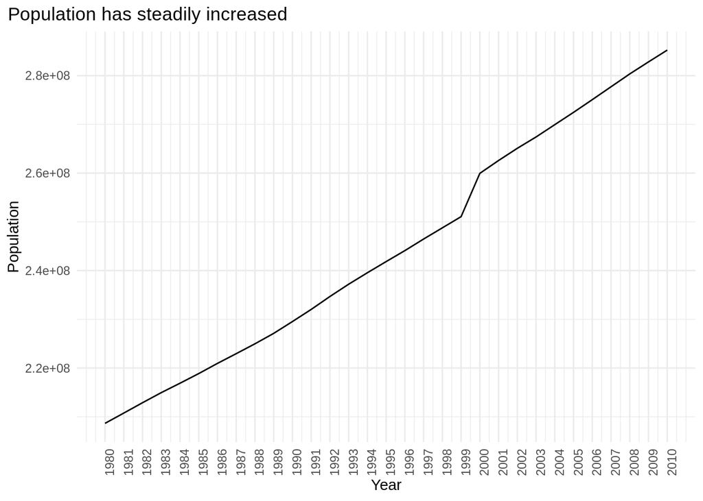

```r
# groups data by how population has changed over the years
df <- DONOHUE_DF |>
  group_by(YEAR) |>
  summarise(Population = sum(Population))

# plots the data with year on x-axis and population on y-axis
# uses a line graph to show change over time
ggplot(df, aes(x = YEAR, y = Population)) +
  geom_line() +
  scale_x_continuous(
    breaks = seq(1980, 2010, by = 1),
    limits = c(1980, 2010),
    labels = c(seq(1980, 2010, by = 1))
  ) +
  labs(
    title = "Population has steadily increased",
    x = "Year",
    y = "Population"
  ) +
  theme_minimal() +
  theme(axis.text.x = element_text(angle = 90),
        plot.title.position = "plot")
```

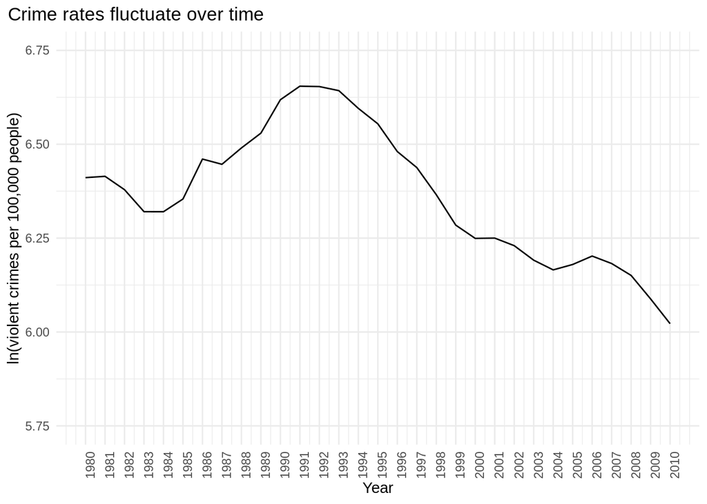

```r
# groups data by crime count per 100,000 people
df <- DONOHUE_DF |>
  group_by(YEAR) |>
  summarize(
    Viol_crime_count = sum(Viol_crime_count),
    Population = sum(Population),
    .groups = "drop"
  ) |>
  mutate(Viol_crime_rate_100k_log = log((Viol_crime_count * 100000) / Population))

# plots the year on the x-axis and violent crime rates per 100k people on y-axis
# uses a line graph to show change over time
df |>
  ggplot(aes(x = YEAR, y = Viol_crime_rate_100k_log)) +
  geom_line() +
  scale_x_continuous(
    breaks = seq(1980, 2010, by = 1),
    limits = c(1980, 2010),
    labels = c(seq(1980, 2010, by = 1))
  ) +
  scale_y_continuous(
    breaks = seq(5.75, 6.75, by = 0.25),
    limits = c(5.75, 6.75)
  ) +
  labs(
    title = "Crime rates fluctuate over time",
    x = "Year",
    y = "ln(violent crimes per 100,000 people)"
  ) +
  theme_minimal() +
  theme(axis.text.x = element_text(angle = 90), plot.title.position = "plot")
```

In the graph below, we see how the violent crime rate changes over time between the different states. The most noticable pattern is that the crime rate seems to stay consistent between most states from 1980 until 2010. However, there are some exceptions such as the blue line at the bottom of the graph which steadily increases from 1980 to 2010.

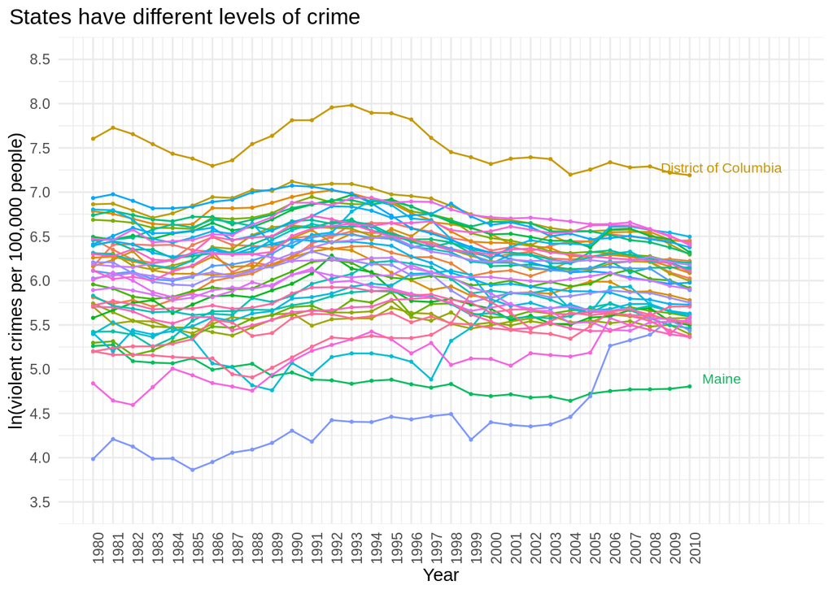

```r
# groups data by crime count per 100k people
# also plots the violent crime rate change over time for each of the states
# plots year on the x-axis and crime rate per 100k people on the y-axis
p <- DONOHUE_DF |>
  mutate(Viol_crime_rate_100k_log = log((Viol_crime_count * 100000) / Population)) |>
  ggplot(aes(x = YEAR, y = Viol_crime_rate_100k_log, color = STATE)) +
  geom_point(size = 0.5) +
  geom_line(aes(group = STATE),
    size = 0.5,
    show.legend = FALSE
  ) +
  geom_text_repel(data = DONOHUE_DF |>
      mutate(Viol_crime_rate_100k_log = log((Viol_crime_count * 100000) / Population)) |>
      filter(YEAR == last(YEAR)),
      aes(label = STATE,x = YEAR, y = Viol_crime_rate_100k_log),
      size = 3, alpha = 1, nudge_x = 1, direction = "y",
      hjust = 1, vjust = 1, segment.size = 0.25, segment.alpha = 0.25,
      force = 1, max.iter = 9999)

p +
  guides(color = "none") +
  scale_x_continuous(
    breaks = seq(1980, 2015, by = 1),
    limits = c(1980, 2015),
    labels = c(seq(1980, 2010, by = 1), rep("", 5))
  ) +
  scale_y_continuous(
    breaks = seq(3.5, 8.5, by = 0.5),
    limits = c(3.5, 8.5)
  ) +
  labs(
    title = "States have different levels of crime",
    x = "Year", y = "ln(violent crimes per 100,000 people)"
  ) +
  theme_minimal() +
  theme(axis.text.x = element_text(angle = 90), plot.title.position = "plot")
```

In the graph below, we observe how the police presence has been increasing over time per 100,000 people since 1980 with only a few fluctuations from 1996 to 2010. We can see that police presence has increased significantly from sub-10,000 to as high as 16,000.

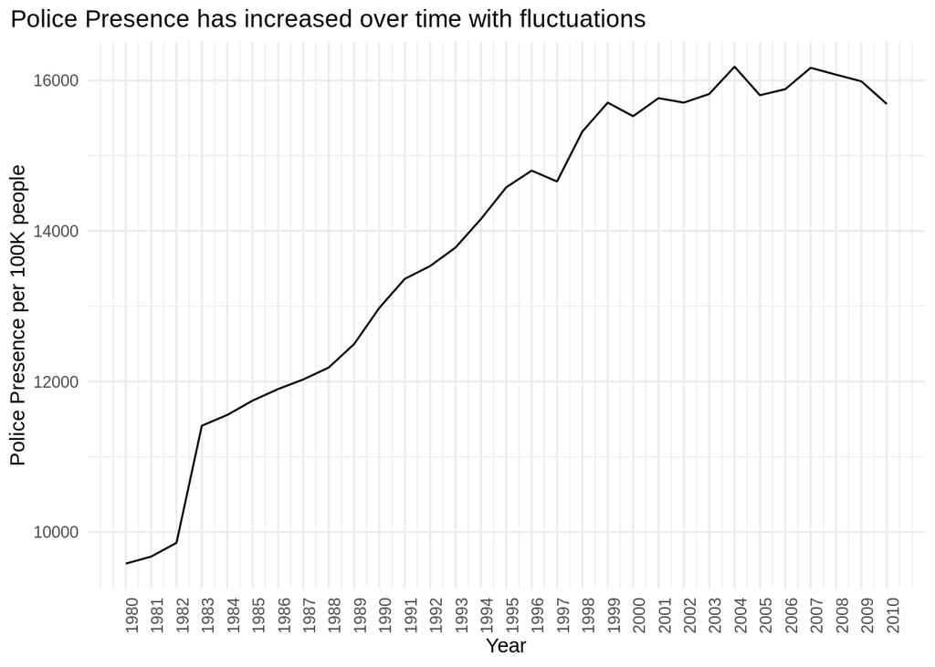

```r
# groups data by police presence per 100k people
# plots the police presence over time per 100k people since 1980
# year is on the x-axis and police presence per 100k people on the y-axis
p <- DONOHUE_DF |>
  group_by(YEAR) |>
  summarise(Police = sum(police_per_100k_lag)) |>
  ggplot(aes(x = YEAR, y = Police)) +
  geom_line() +
  scale_x_continuous(
    breaks = seq(1980, 2010, by = 1),
    limits = c(1980, 2010),
    labels = c(seq(1980, 2010, by = 1))
  )
p +
  labs(
    title = "Police Presence has increased over time with fluctuations",
    x = "Year",
    y = "Police Presence per 100K people"
  ) +
  theme_minimal() +
  theme(axis.text.x = element_text(angle = 90),
        plot.title.position = "plot")
```

### Data Analysis

To begin our analysis in determining the effect of multicollinearity in our data set, we decided to do panel linear regression models. We started with the Donohue data and needed to get it in a form that can go through our panel linear model function.

```r
d_panel_DONOHUE <- pdata.frame(DONOHUE_DF, index = c("STATE", "YEAR"))
class(d_panel_DONOHUE)
```

```
## [1] "pdata.frame" "data.frame"
```

Now that our data is ready, we ran a panel linear regression model on the Donohue data and summarized it in a tibble.

```r
# Run Panel Linear Regression
DONOHUE_OUTPUT <- plm(Viol_crime_rate_1k_log ~
                      RTC_LAW +
                      White_Male_15_to_19_years +
                      White_Male_20_to_39_years +
                      Black_Male_15_to_19_years +
                      Black_Male_20_to_39_years +
                      Other_Male_15_to_19_years +
                      Other_Male_20_to_39_years +
                      Unemployment_rate +
                      Poverty_rate +
                      Population_log +
                      police_per_100k_lag,
                      effect = "twoways",
                      model = "within",
                      data = d_panel_DONOHUE)
DONOHUE_OUTPUT_TIDY <- tidy(DONOHUE_OUTPUT, conf.int = 0.95) # Clean up output
DONOHUE_OUTPUT_TIDY$Analysis <- "Analysis Donohue" # Add column showing the observations came from the Donahue data set
DONOHUE_OUTPUT_TIDY # Display results
```

```
## # A tibble: 11 × 8
##    term       estimate std.error statistic  p.value conf.low conf.high Analysis
##    <chr>         <dbl>     <dbl>     <dbl>    <dbl>    <dbl>     <dbl> <chr>
##  1 RTC_LAWT…  0.0240    0.0170       1.42  1.56e- 1 -9.19e-3  0.0573   Analysis…
##  2 White_Ma…  0.0104    0.0282       0.367 7.13e- 1 -4.49e-2  0.0656   Analysis…
##  3 White_Ma…  0.0293    0.0100       2.93  3.50e- 3  9.68e-3  0.0490   Analysis…
##  4 Black_Ma… -0.0597    0.0578      -1.03  3.02e- 1 -1.73e-1  0.0536   Analysis…
##  5 Black_Ma…  0.123     0.0195       6.34  3.17e-10  8.53e-2  0.162    Analysis…
##  6 Other_Ma…  0.674     0.114        5.92  4.15e- 9  4.51e-1  0.897    Analysis…
##  7 Other_Ma… -0.304     0.0383      -7.95  4.21e-15 -3.79e-1 -0.229    Analysis…
##  8 Unemploy… -0.0171    0.00498     -3.42  6.36e- 4 -2.68e-2 -0.00729  Analysis…
##  9 Poverty_… -0.00760   0.00299     -2.54  1.12e- 2 -1.35e-2 -0.00174  Analysis…
## 10 Populati… -0.211     0.0617      -3.42  6.55e- 4 -3.32e-1 -0.0899   Analysis…
## 11 police_p…  0.000559  0.000140     4.00  6.72e- 5  2.85e-4  0.000833 Analysis…
```

We next prepared our Lott data for a panel linear regression as well by first determining our variables from the Lott data set, wrangling the data for the panel linear model function, and running the panel linear regression.

```r
# Determine variables from data set
LOTT_variables <- LOTT_DF |>
  # Select desired columns
  select(RTC_LAW,
         contains(c("White", "Black", "Other")),
         Unemployment_rate,
         Poverty_rate,
         Population_log,
         police_per_100k_lag) |>
  colnames() # Extract the column names
LOTT_fmla <- as.formula(paste("Viol_crime_rate_1k_log ~", paste(LOTT_variables, collapse = " + ") # Assign variables in form for plm function
))
# Prepare data
d_panel_LOTT <- pdata.frame(LOTT_DF, index = c("STATE", "YEAR"))
# Run panel linear regression
LOTT_OUTPUT <- plm(LOTT_fmla,
                   model = "within",
                   effect = "twoways",
                   data = d_panel_LOTT
)
LOTT_OUTPUT_TIDY <- tidy(LOTT_OUTPUT, conf.int = 0.95)
LOTT_OUTPUT_TIDY$Analysis <- "Analysis Lott"
LOTT_OUTPUT_TIDY
```

```
## # A tibble: 41 × 8
##    term       estimate std.error statistic  p.value conf.low conf.high Analysis
##    <chr>         <dbl>     <dbl>     <dbl>    <dbl>    <dbl>     <dbl> <chr>
##  1 RTC_LAWTR… -0.0518     0.0162    -3.20  1.39e- 3  -0.0835   -0.0201 Analysis…
##  2 White_Fem…  0.636      0.149      4.26  2.24e- 5   0.343     0.929  Analysis…
##  3 White_Fem…  0.00698    0.0670     0.104 9.17e- 1  -0.124     0.138  Analysis…
##  4 White_Fem…  0.261      0.0813     3.21  1.38e- 3   0.101     0.420  Analysis…
##  5 White_Fem…  0.0168     0.0814     0.206 8.37e- 1  -0.143     0.176  Analysis…
##  6 White_Fem… -0.459      0.0625    -7.35  3.60e-13  -0.582    -0.337  Analysis…
##  7 White_Fem…  0.156      0.0469     3.33  9.04e- 4   0.0641    0.248  Analysis…
##  8 White_Mal… -0.583      0.143     -4.07  4.92e- 5  -0.863    -0.302  Analysis…
##  9 White_Mal…  0.0639     0.0623     1.03  3.05e- 1  -0.0582    0.186  Analysis…
## 10 White_Mal… -0.200      0.0859    -2.33  2.01e- 2  -0.368    -0.0315 Analysis…
## # … with 31 more rows
```

Now that we have ran a regression on both the Donahue and Lott data, we want to look at a comparison between the two to gather further insights.

```r
# Combine the data into a single tibble with only the RTC_LAWTRUE row
comparing_analyses <- DONOHUE_OUTPUT_TIDY |>
  bind_rows(LOTT_OUTPUT_TIDY) |>
  filter(term == "RTC_LAWTRUE")
comparing_analyses
```

```
## # A tibble: 2 × 8
##   term      estimate std.error statistic p.value conf.low conf.high Analysis
##   <chr>        <dbl>     <dbl>     <dbl>   <dbl>    <dbl>     <dbl> <chr>
## 1 RTC_LAWT…   0.0240    0.0170      1.42 0.156   -0.00919    0.0573 Analysis Do…
## 2 RTC_LAWT…  -0.0518    0.0162     -3.20 0.00139 -0.0835    -0.0201 Analysis Lo…
```

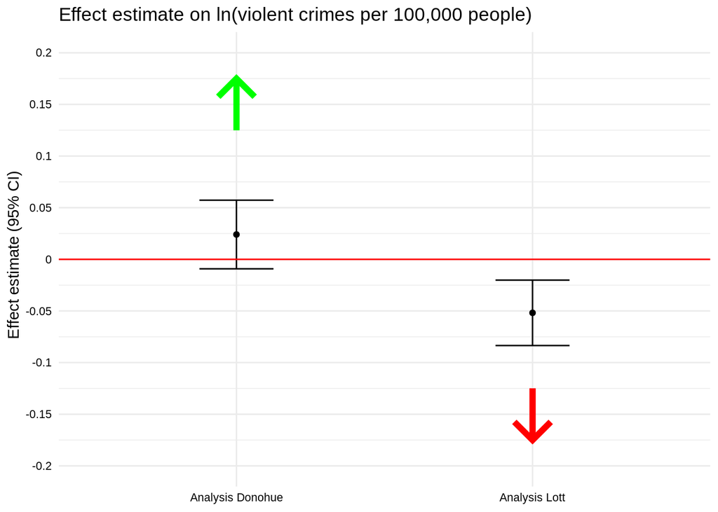

```r
# Plot confidence intervals of both Donahue and Lott data
ggplot(comparing_analyses) +
  geom_point(aes(x = Analysis, y = estimate)) +
  geom_errorbar(aes(x = Analysis, ymin = conf.low, ymax = conf.high), width = 0.25) +
  geom_hline(yintercept = 0, color = "red") +
  scale_y_continuous(
    breaks = seq(-0.2, 0.2, by = 0.05),
    labels = seq(-0.2, 0.2, by = 0.05),
    limits = c(-0.2, 0.2)
  ) +
  # Add arrows
  geom_segment(aes(x = 1, y = 0.125, xend = 1, yend = 0.175),
    arrow = arrow(angle = 45, ends = "last", type = "open"),
    size = 2, color = "green", lineend = "butt", linejoin = "mitre"
  ) +
  geom_segment(aes(x = 2, y = -0.125, xend = 2, yend = -0.175),
    arrow = arrow(angle = 45, ends = "last", type = "open"),
    size = 2, color = "red", lineend = "butt", linejoin = "mitre"
  ) +
  # Set theme
  theme_minimal() +
  theme(
    axis.title.x = element_blank(),
    axis.text = element_text(size = 8, color = "black")
  ) +
  # Add labels
  labs(
    title = "Effect estimate on ln(violent crimes per 100,000 people)",
    y = "  Effect estimate (95% CI)"
  )
```

From this plot, we see that the means and confidence intervals for the Donohue and Lott data differ notably. In fact, the coefficient for Right To Carry (RTC) Laws in the Donohue analysis is positive while it is negative in the Lott analysis. The data seems to be contradictory. The differences between the data is Donohue contains males only, ages 15 to 39. Lott contains males and females, ages 10-65+. These are some interesting differences and seeing the value of the coefficients for RTC laws in both data sets, we decided to test for multicollinearity.

To begin our diagnosis, we started plotting a pairplot for the Donohue data set.

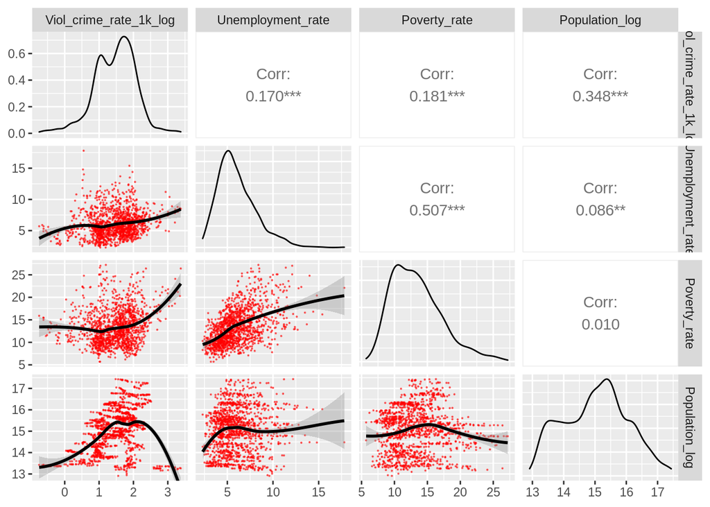

```r
DONOHUE_DF |>
  # Select necessary columns for our analysis
  select(RTC_LAW,
         Viol_crime_rate_1k_log,
         Unemployment_rate,
         Poverty_rate,
         Population_log) |>
  # Plot pairplot
  ggpairs(columns = c(2:5),
          lower = list(continuous = wrap("smooth_loess",
                                         color = "red",
                                         alpha = 0.5,
                                         size = 0.1)))
```

Seeing the results from the pairplot, we decided to take a deeper dive in our visualizations by creating heat maps for both the Donohue and Lott data sets to get better insights on if collinearity seems to appear within race and age.

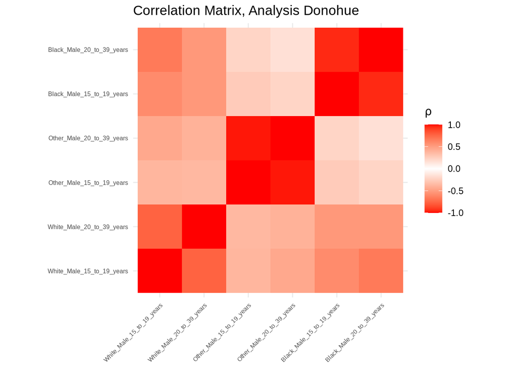

```r
## Donahue data
# Extract correlation from data set
cor_DONOHUE_dem <- cor(DONOHUE_DF |> select(contains("_years")))
# Plot heat map
ggcorrplot(cor_DONOHUE_dem,
  tl.cex = 6,
  hc.order = TRUE,
  colors = c(
    "red",
    "white",
    "red"
  ),
  outline.color = "transparent", # Set color opacity
  title = "Correlation Matrix, Analysis Donohue", # Set title
  legend.title = expression(rho) # Set legend title
)
```

There seems to be a relatively strong correlation with race, regardless of age as the correlation remains close to one (red squares) within race and accross age groups. This can suggest collinearity because there is a strong relationship for race.

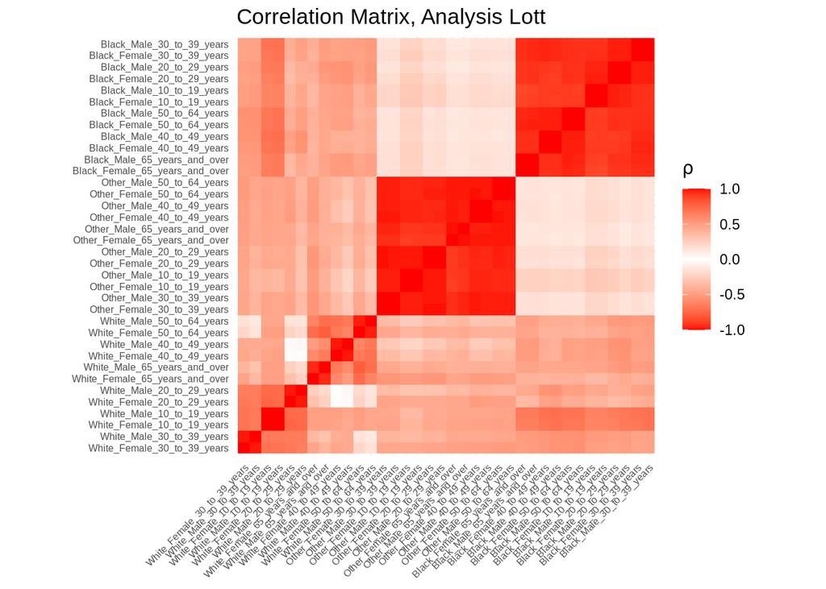

```r
## Lott data
# Extract correlation from data set
cor_LOTT_dem <- cor(LOTT_DF |> select(contains("_years")))
# Plot heat map
corr_mat_LOTT <- ggcorrplot(cor_LOTT_dem,
  tl.cex = 6,
  hc.order = TRUE,
  colors = c(
    "red",
    "white",
    "red"
  ),
  outline.color = "transparent", # Set color opacity
  title = "Correlation Matrix, Analysis Lott", # Set title
  legend.title = expression(rho) # Set legend title
)
corr_mat_LOTT
```

The Donohue data set only shows observation for males, so we are not able to compare across gender; however, the Lott data set does. We can see similar conclusions in that there is a strong correlation within race, regardless of gender for Black and Other racial groups, as seen by the big red squares in the middle and top right of the chart. With Whites, there is still a relatively strong correlation within race, across gender and age but not as strong as the other racial groups. The Lott data compliments the Donohue data in concluding that there may be collinearity due to our findings with race.

From our initial analysis we see that there may be multicollinearity, so we decided to test for it via Bootstrapping. We began by splitting the data.

```r
set.seed(124) # Set seed for RNG state
DONOHUE_splits <- d_panel_DONOHUE |> loo_cv() # Leave one out cross validation
DONOHUE_splits
```

```
## # Leave-one-out cross-validation
## # A tibble: 1,364 × 2
##    splits           id
##    <list>           <chr>
##  1 <split [1363/1]> Resample1
##  2 <split [1363/1]> Resample2
##  3 <split [1363/1]> Resample3
##  4 <split [1363/1]> Resample4
##  5 <split [1363/1]> Resample5
##  6 <split [1363/1]> Resample6
##  7 <split [1363/1]> Resample7
##  8 <split [1363/1]> Resample8
##  9 <split [1363/1]> Resample9
## 10 <split [1363/1]> Resample10
## # … with 1,354 more rows
```

We next pulled the split data.

```r
DONOHUE_subsets <- map(pull(DONOHUE_splits, splits), training)
glimpse(DONOHUE_subsets[[1]])
```

```
## Rows: 1,363
## Columns: 20
## $ YEAR                      <fct> 1980, 1981, 1982, 1983, 1984, 1985, 1986, 19…
## $ STATE                     <fct> Alaska, Alaska, Alaska, Alaska, Alaska, Alas…
## $ Black_Male_15_to_19_years <pseries> 0.1670456, 0.1732299, 0.1737069, 0.17095…
## $ Black_Male_20_to_39_years <pseries> 0.9933775, 1.0028219, 1.0204445, 1.03127…
## $ Other_Male_15_to_19_years <pseries> 1.1297816, 1.1244412, 1.0698208, 0.98828…
## $ Other_Male_20_to_39_years <pseries> 2.963329, 2.974775, 3.015071, 3.008048, …
## $ White_Male_15_to_19_years <pseries> 3.627805, 3.558261, 3.391844, 3.222002, …
## $ White_Male_20_to_39_years <pseries> 18.28852, 18.12821, 18.10666, 17.90600, …
## $ Unemployment_rate         <pseries> 9.6, 9.4, 9.9, 9.9, 9.8, 9.7, 10.9, 10.3…
## $ Poverty_rate              <pseries> 9.6, 9.0, 10.6, 12.6, 9.6, 8.7, 11.4, 12…
## $ Viol_crime_count          <pseries> 1919, 2537, 2732, 2940, 3108, 3031, 3046…
## $ Population                <pseries> 404680, 418519, 449608, 488423, 513697, …
## $ police_per_100k_lag       <pseries> 194.7218, 200.2299, 191.0553, 364.2335, …
## $ RTC_LAW_YEAR              <pseries> 1995, 1995, 1995, 1995, 1995, 1995, 1995…
## $ RTC_LAW                   <pseries> FALSE, FALSE, FALSE, FALSE, FALSE, FALSE…
## $ TIME_0                    <pseries> 1980, 1980, 1980, 1980, 1980, 1980, 1980…
## $ TIME_INF                  <pseries> 2010, 2010, 2010, 2010, 2010, 2010, 2010…
## $ Viol_crime_rate_1k        <pseries> 4.742018, 6.061851, 6.076404, 6.019373, …
## $ Viol_crime_rate_1k_log    <pseries> 1.556463, 1.802015, 1.804413, 1.794983, …
## $ Population_log            <pseries> 12.91085, 12.94448, 13.01613, 13.09894, …
```

To run our bootstrapping, we created a function for Donahue data for panel linear regression to make our lives easier.

```r
# Create function for Donahue data
fit_nls_on_bootstrap_DONOHUE <- function(subset) {
  # Run panel linear regression
  plm(Viol_crime_rate_1k_log ~ RTC_LAW +
        White_Male_15_to_19_years +
        White_Male_20_to_39_years +
        Black_Male_15_to_19_years +
        Black_Male_20_to_39_years +
        Other_Male_15_to_19_years +
        Other_Male_20_to_39_years +
        Unemployment_rate +
        Poverty_rate +
        Population_log +
        police_per_100k_lag,
      data = data.frame(subset),
      index = c("STATE", "YEAR"),
      model = "within",
      effect = "twoways")
}
```

Now that we have our function, we ran it on our Donahue data subset.

```r
subsets_models_DONOHUE <- map(DONOHUE_subsets, fit_nls_on_bootstrap_DONOHUE)
subsets_models_DONOHUE <- subsets_models_DONOHUE |>
  map(tidy)
```

Knowing that it takes a while to run this code chunk, we saved the output.

```r
save(subsets_models_DONOHUE,
  file = "data/wrangled/DONOHUE_simulations.rda")
```

We ran the same analysis with Bootstrapping on the Lott data for the same reason. Starting by splitting and pulling the data.

```r
set.seed(124) # Set seed for RNG state
# Leave one out cross validation
LOTT_splits <- d_panel_LOTT |> loo_cv()
# Pull split data
LOTT_subsets <- map(pull(LOTT_splits, splits), training)
```

Same as for Donahue, we created a Bootstrapping function for the Lott data.

```r
# Create function for Donahue data
fit_nls_on_bootstrap_LOTT <- function(split) {
    # Run panel linear regression
  plm(LOTT_fmla,
      data = data.frame(split),
      index = c("STATE", "YEAR"),
      model = "within",
      effect = "twoways"
  )
}
```

Now that we have our function, we ran it on our Lott data subset.

```r
subsets_models_LOTT <- map(LOTT_subsets, fit_nls_on_bootstrap_LOTT)
subsets_models_LOTT <- subsets_models_LOTT |>
  map(tidy)
```

Saved the output.

```r
save(subsets_models_LOTT,
  file = "data/wrangled/LOTT_simulations.rda")
```

Setting the names of the model objects accordingly.

```r
names(subsets_models_DONOHUE) <- paste0("DONOHUE_", seq_len(length(subsets_models_DONOHUE)))
names(subsets_models_LOTT) <-
  paste0("LOTT_", 1:length(subsets_models_LOTT))
```

For further analysis, we decided to combine our simulation data.

```r
# Specify Donohue Data
simulations_DONOHUE <- subsets_models_DONOHUE |>
  bind_rows(.id = "ID") |>
  mutate(Analysis = "Analysis Donohue")
# Specify Lott data
simulations_LOTT <- subsets_models_LOTT |>
  bind_rows(.id = "ID") |>
  mutate(Analysis = "Analysis Lott")
# Combine Donohue and Lott Data
simulations <- bind_rows(simulations_DONOHUE, simulations_LOTT)
# Order for easier comparison
simulations <- simulations |>
  mutate(term = factor(term,
    levels = c(
      str_subset(unique(pull(simulations, term)), "years", negate = TRUE),
      sort(str_subset(unique(pull(simulations, term)), "years")))))
```

Now that we have our combined data, we plotted the coefficients for both Donohue and Lott data to visualize potential collinearity.

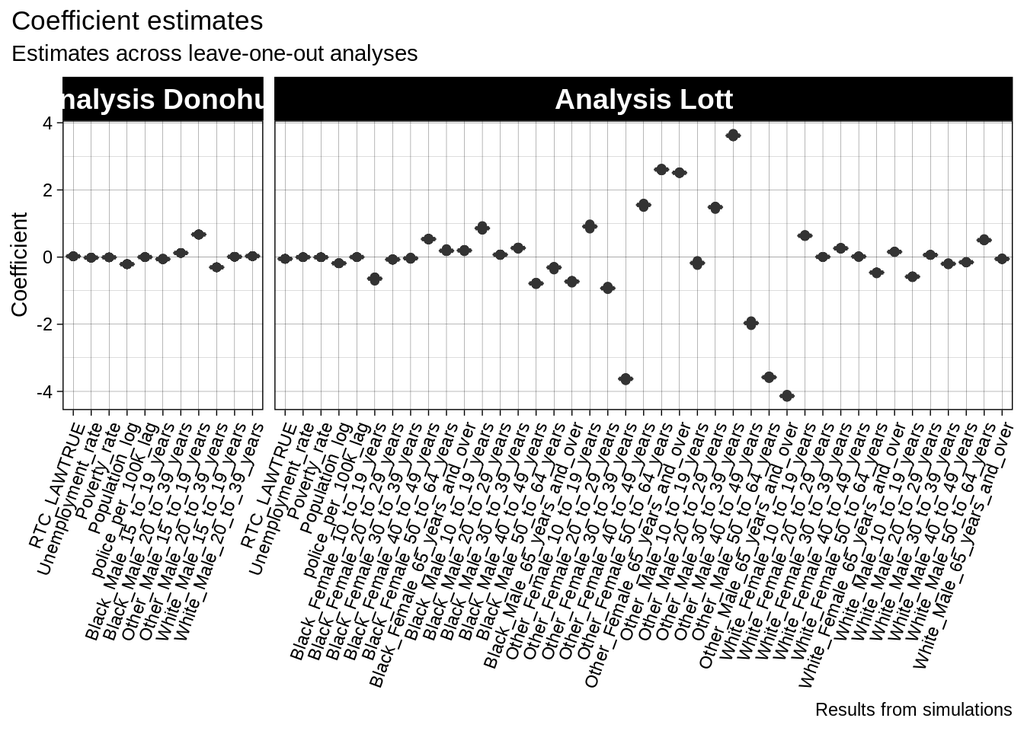

```r
simulations |>
  # Create a boxplot for simulation coefficients
  ggplot(aes(x = term, y = estimate)) +
  geom_boxplot() +
  facet_grid(. ~ Analysis, scale = "free_x", space = "free", drop = TRUE) + # Allow axes to vary freely
  # Set labels
  labs(title = "Coefficient estimates",
       subtitle = "Estimates across leave-one-out analyses",
       x = "Term",
       y = "Coefficient",
       caption = "Results from simulations") +
  # Set theme
  theme_linedraw() +
  theme(axis.title.x = element_blank(),
        axis.text.x = element_text(angle = 70, hjust = 1),
        strip.text.x = element_text(size = 14, face = "bold"),
        plot.title.position="plot")
```

For the Donohue data, we see that both Other Male age groups have a relatively higher coefficient absolute value in comparison to the other variables, which have coefficients of about 0. Have this relatively high magnitude coefficients show that there is likely collinearity in the Donohue data.

For the Lott data, we can see a similar trend as the absolute value for the coefficients of the Other Race variables, regardless of gender and age group, are relatively high compared to the other variables in the data. There seems to also be rather high coefficients for the variables in the Black racial group, which can also seem to show collinearity, but the biggest tell of collinearity is the Other Race variables as those coefficients are much higher than even the variables within the Black race.

We then created a similar plot for the standard deviation of the coefficients according to the simulation.

```r
# Extract standard deviation from data
coeff_sd <- simulations |>
  group_by(Analysis, term) |>
  summarize("SD" = sd(estimate))
```

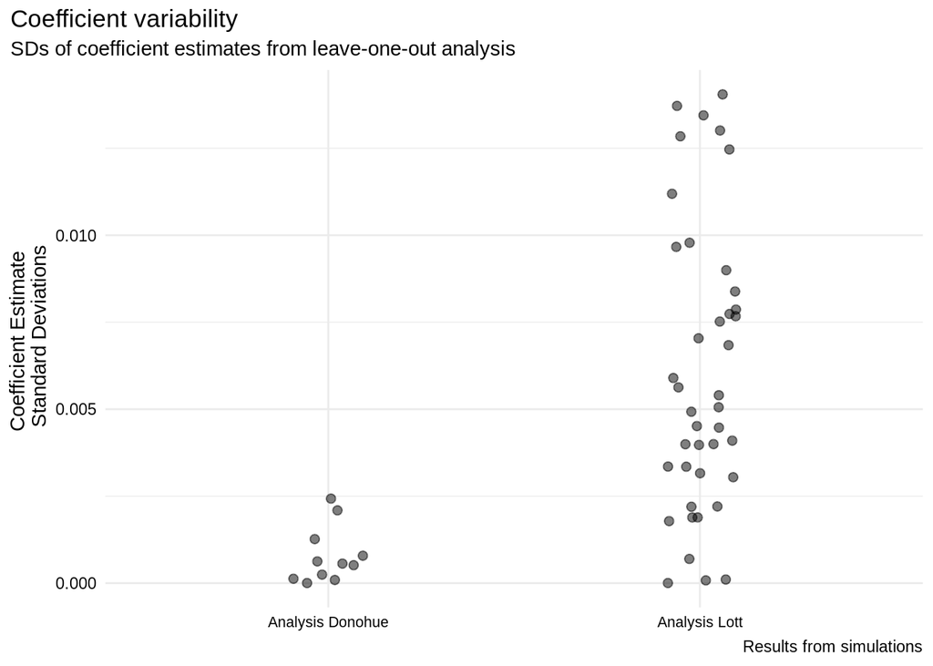

```r
# Plot standard deviation
coeff_sd |>
  ggplot(aes(x = Analysis, y = SD)) +
  geom_jitter(width = 0.1, alpha = 0.5, size = 2) + # Add jitter
  # Set labels
  labs(title = "Coefficient variability",
       subtitle = "SDs of coefficient estimates from leave-one-out analysis",
       x = "Term",
       y = "Coefficient Estimate \n Standard Deviations",
       caption = "Results from simulations") +
  # Set theme
  theme_minimal() +
  theme(axis.title.x = element_blank(),
        axis.text.x = element_text(size = 8, color = "black"),
        axis.text.y = element_text(color = "black"),
        plot.title.position="plot")
```

As we can see the Lott dataset contains variables that have more deviation meaning they are more spread out, while the Donohue dataset has variables that are more centered.

To determine how much of the variance is determined by collinearity, we calculated the Variance Inflation Factor (VIF) for the Donohue data.

```r
# Create Donohue model matrix
lm_DONOHUE_data <- as.data.frame(model.matrix(DONOHUE_OUTPUT))
# Define regression model
lm_DONOHUE_data <- lm_DONOHUE_data |>
  mutate(Viol_crime_rate_1k_log = plm::Within(pull(
    d_panel_DONOHUE, Viol_crime_rate_1k_log
  )), effect = "twoways")

# Specify Donohue model
lm_DONOHUE <- lm(Viol_crime_rate_1k_log ~
RTC_LAWTRUE +
  White_Male_15_to_19_years +
  White_Male_20_to_39_years +
  Black_Male_15_to_19_years +
  Black_Male_20_to_39_years +
  Other_Male_15_to_19_years +
  Other_Male_20_to_39_years +
  Unemployment_rate +
  Poverty_rate +
  Population_log +
  police_per_100k_lag,
data = lm_DONOHUE_data
)

# Calculate VIF for Donohue data
vif_DONOHUE <- vif(lm_DONOHUE)

# Clean result into a table
vif_DONOHUE <- vif_DONOHUE |>
  as_tibble() |>
  cbind(names(vif_DONOHUE)) |>
  as_tibble()
colnames(vif_DONOHUE) <- c("VIF", "Variable") # Set column names
vif_DONOHUE
```

```
## # A tibble: 11 × 2
##      VIF Variable
##    <dbl> <chr>
##  1  1.11 RTC_LAWTRUE
##  2  1.15 White_Male_15_to_19_years
##  3  1.72 White_Male_20_to_39_years
##  4  1.34 Black_Male_15_to_19_years
##  5  1.66 Black_Male_20_to_39_years
##  6  1.58 Other_Male_15_to_19_years
##  7  1.52 Other_Male_20_to_39_years
##  8  1.23 Unemployment_rate
##  9  1.27 Poverty_rate
## 10  1.17 Population_log
## 11  1.21 police_per_100k_lag
```

Overall, all these regression coefficients have a VIF value close to 1.0 meaning that is weak multicollinearity.

We similarly calculated the VIF for the Lott data.

```r
# Create Lott model matrix
lm_LOTT_data <- as.data.frame(model.matrix(LOTT_OUTPUT))
# Define regression model
lm_LOTT_data <- lm_LOTT_data |>
  mutate(Viol_crime_rate_1k_log = plm::Within(pull(d_panel_LOTT, Viol_crime_rate_1k_log), effect = "twoways")) |>
  rename(RTC_LAW = RTC_LAWTRUE)
# Specify Lott model
lm_LOTT <- lm(LOTT_fmla, data = lm_LOTT_data)

# Calculate VIF for Lott data
vif_LOTT <- vif(lm_LOTT)
# Convert LOTT data into tibble
vif_LOTT <- vif_LOTT |>
  as_tibble()  |>
  cbind(names(vif_LOTT))  |>
  as_tibble()
# Assign column names
colnames(vif_LOTT) <- c("VIF", "Variable")

# Clean result into a table
vif_LOTT |>
  mutate(Variable = str_replace(string = Variable,
                                pattern = "RTC_LAW",
                                replacement = "RTC_LAWTRUE"))
```

```
## # A tibble: 41 × 2
##       VIF Variable
##     <dbl> <chr>
##  1   1.61 RTC_LAWTRUE
##  2 121.   White_Female_10_to_19_years
##  3  47.2  White_Female_20_to_29_years
##  4  49.6  White_Female_30_to_39_years
##  5  36.3  White_Female_40_to_49_years
##  6  34.2  White_Female_50_to_64_years
##  7  11.6  White_Female_65_years_and_over
##  8 120.   White_Male_10_to_19_years
##  9  41.8  White_Male_20_to_29_years
## 10  70.8  White_Male_30_to_39_years
## # … with 31 more rows
```

A large number of regression coefficients have a large VIF value meaning there exists problematic multicollinearity for those variables. The few variables that have a VIF value less than 10 are: RTC_LAW, Unemployment_rate, Poverty_rate, Population_log, and police_per_100k_lag

We then combined our Donohue and Lott data sets to be able visualize VIF values across both data sets.

```r
# Identify as Donohue data
vif_DONOHUE <- vif_DONOHUE |>
  mutate(Analysis = "Analysis Donohue")
# Identify as Lott data
vif_LOTT <- vif_LOTT |>
  mutate(Analysis = "Analysis Lott")
# Combine data
vif_df <- bind_rows(vif_DONOHUE, vif_LOTT)
```

With our combined data, we then plotted the VIF results.

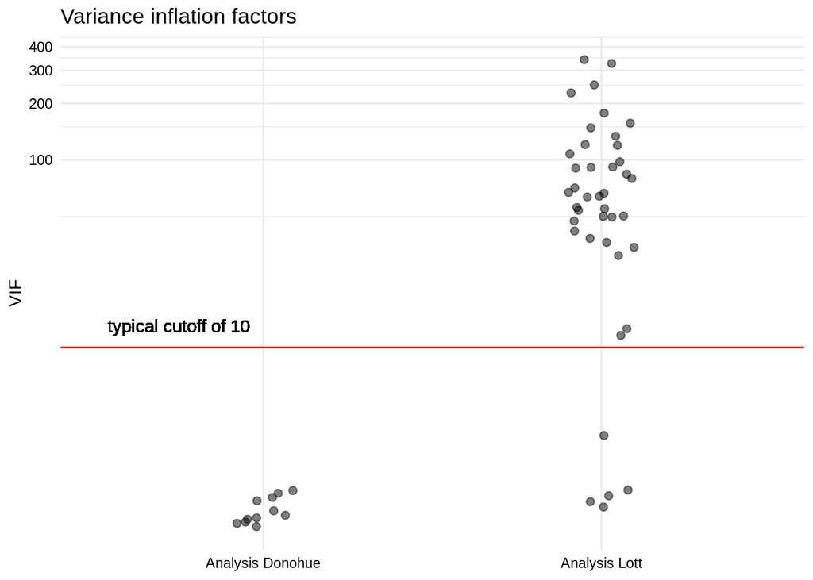

```r
# Plot VIF
vif_df |>
  ggplot(aes(x = Analysis, y = VIF)) +
  geom_jitter(width = 0.1, alpha = 0.5, size = 2) + # Add jitter
  geom_hline(yintercept = 10, color = "red") + # Add horizontal line at VIF Cutoff
  geom_text(aes(.75, 13, label = "typical cutoff of 10")) + # Set label/text
  coord_trans(y = "log10") + # Scale axis
  # Add labels
  labs(title = "Variance inflation factors") +
  # Set theme
  theme_minimal() +
  theme(axis.title.x = element_blank(),
        axis.text.x = element_text(color = "black"),
        axis.text.y = element_text(color = "black"))
```

As we can see, the Lott dataset contains many variables that have a VIF value >= 10 which indicates that there exists problematic multicollinearity. On the other hand, the Donohue dataset does not contain any variables with a VIF value that is >= 10.

## Conclusion

From our initial exploratory data analysis, we were able to see minor correlations between variables, but were not able to visually see a strong case for multicollinearity between variables. We decided to drill down in our mathematical data analysis to see if there was any multicollinearity when analyzing right to carry laws and violence rates. Although our Donohue and Lott data sets seemed to contradict each other in terms of the value and sign of the regression coefficient for right to carry laws, they did agree in whether there is multicollinearity in our variables through our initial visualizations as there was a strong correlation within race in both data sets. In doing a VIF analysis, we took an even deeper dive in determining multicollinearity and found that the magnitude of our regression coefficients in the Donohue was not significant with VIF values all below 10, but in the Lott data set, we did see variables with VIF values above 10, which would imply multicollinearity. In the Lott data set, Black Female ages 10-19 had the highest multicollinearity along with other variables within the Black and Other race variables.